# Meetup Data Analysis

## Problem Statement

Meetup Data Analysis for Countries trending in Innovation

## Pre-requisites

- Meetup API key
- External Libraries Required: pycountry
- Internet Connection

## 1. Task - Choosing one or more suitable web API

### 1.1. API Used:

- [Wikipedia API](https://www.mediawiki.org/wiki/API:Main_page) has been used to find out the countries list trending on Innovation.
- [Meetup API](https://www.meetup.com/meetup_api/) is used using an API key to analyze and compare statistics of these countries. The API key is listed below.
- Analyzing Meetups Data Trends for countries interested in innovation in the last one year.

```python
api_key = "29191b3c116b165929763e304f2897e"
```

### 1.2. Constraints:

- The use of Wikipedia API is limited and used for finding out the countries listed as most innovative in 2017.
- The data from Wikipedia is subject to change and also the format may change with a change in revision.
- This project involves Well-Supported API for wikipedia, see details below
- These API's data keeps on changing and for analysis purposes, data for below period is used:

  **Wikipedia Data:**

  ```
    Revision Date: 06-01-2018
    Page Title: Global_Innovation_Index
  ```

  **Meetup Data:**

  ```
    Recent Data
  ```

### 1.3. Pre Installations:

- pip install pycountry
- pip install meetup-api
- pip install squarify

```python
import pandas as pd
from pandas.io.json import json_normalize
import urllib.request
import json
import time
import os
```

## 2. Task - Collect data from One or more choosen Web API(s)

#### Import Librabies for fetching data from Rest API

```python
# this is a general class which can be used by all the other classes for fetching data

class api_request:
    def request_data(self,url):
        '''
        Parameters: url
        return: data fetched from api in json format
        ----------
        To request data from a URL though HTTP request and parse it into json format
        '''
        try:
            response = urllib.request.urlopen(url)       #Hit URL: url
            raw_json = response.read().decode()          #Decode response
            data = json.loads(raw_json)
            return data                                  #return data

        except Exception as h:
            print("Cannot find data at given URL\nError:"+str(h))      # Handle exception and return noting if
            return ""                                                  # data is not found at given URL
```

### 2.1. Data Fetch from Wikipedia Page - Global Innovation Index

##### (Custom Class Used Later)

```python
class Wiki(api_request):
    def __init__(self):
        self.__apiurl = "https://en.wikipedia.org/w/api.php"     # API Url
        self.__datatype = "json"                                 # default format to Fetch data: json


    def get_wiki_page(self,page_title="Global_Innovation_Index"):
        '''
        Parameters: page_title (page title of wikipedia article)
        return: json response
        ----------
        To get the data from WIKI API using the parameters: pagetitle and format

        '''
        url_params = "?action=parse&prop=text&page="+page_title+"&format="+self.__datatype
        url= self.__apiurl +  url_params
        return self.request_data(url)
```

### 2.2. Data Fetch from Meet up - Various Content

##### (Custom Class Used Later)

```python
# meetup-api is wrapper on top of the meetup Http api and it uses an api key to establish connection and get response

class Meetup(api_request):
    def __init__(self):
        self.__apiurl = "https://api.meetup.com"
        self.__apikey = "29191b3c116b165929763e304f2897e"                      #API key for meetup used to get the data
        self.__client = meetup.api.Client(self.__apikey,overlimit_wait=True)   #get client from API key to execute API

    def refresh_connection(self):
        '''refresh client if expired, this was required to make sure
           data is fetched consistently and the code does not stop in case of any exception from api
        '''
        self.__client = meetup.api.Client(self.__apikey,overlimit_wait=True)

    def get_categories(self):
        '''
        return: dataframe
        --------
        Method to get all the meetup categories
        '''
        a = self.__client.GetCategories()
        categories_df = pd.read_json(json.dumps(a.results))
        return categories_df

    def get_cities(self, code):
        '''
        Parameters: country code
        return: dataframe
        ---------
        Method to get cities for the country using parameter: country alpha_2 code
        '''
        cities = self.__client.GetCities(country=code)
        cities_df = pd.read_json(json.dumps(cities.results))
        return cities_df

    def get_groups(self, cat_id, lat, long, offset_val=0, retrycount=0):
        '''
        Parameters: category id, latitude, longitude, offset value and retry count(max allowed 2)
        return: normalized json
        --------
        Method to get all groups of the city
        '''
        try:
            if retrycount==2:
                print("Max retries reached")            # Check if maximum retries reached, return nothing in that case
                return ""
            retrycount = retrycount + 1
            group = self.__client.GetGroups(category_id = cat_id, lat=lat, lon= long, offset = offset_val)
            return json_normalize(group.results)
        except:
            print("Trying to re-establish connection")
            self.refresh_connection()
            get_groups(self, cat_id, lat, long, offset_val, retrycount)
```

## 3. Task - Parse data, and store it in an appropriate file format

### 3.1. Parse collected data

##### (Custom Class Used Later)

```python
from bs4 import BeautifulSoup
import pycountry

class ParseData:

    def __init__(self):
        '''Initialize {country: country code} disctionary using pycountry module
        '''
        self.__countries_dict={country.name.lower():country.alpha_2.lower() for country in pycountry.countries }

    def wiki_content(self, html):
        '''
        Parameters: html content
        returns: dataframe
        ---------
        Method to parse wikipedia  html content to get top countries which are innovative
        '''
        parsed_html = BeautifulSoup(html,"lxml")
        table = parsed_html.body.find_all('table', attrs={'class':'wikitable'})[0]

        list=[]
        list.extend(table.select('td a'))
        countries_wiki=[]

        for l in list:
            countries_wiki.append(l.text.lower())

        df = pd.DataFrame([countries_wiki],index=['geoName']).T
        df =df.set_index('geoName')

        # After getting the list of countries,
        # creating a dataframe by joining the country list and their aplha 2 code dictionary

        country_df = df.join(pd.DataFrame(self.__countries_dict,index=['code']).rename_axis('geoName').T , how='inner')
        return country_df

    def get_countries_dict(self):
        '''
        returns {country code: country} disctionary using pycountry module
        '''
        return {country.alpha_2.upper():country.name for country in pycountry.countries }
```

### 3.2. Data Store

##### (Custom Class Used Later)

```python
class DataStore:

    def __init__(self):
        self.__datapath = os.getcwd() + "\data"
        self.__pathObj = {
            'wiki' : self.__datapath + "\wiki",
            'meetup': self.__datapath + "\meetup"
        }
        #Create required directories for meetup data and wikipedia data
        for k,v in self.__pathObj.items():
            os.makedirs(v, exist_ok=True)

    def df_to_csv(self, df, data_dir, filename, index=True):
        '''
        Parameters: data frame, directory name, file name and if index column is required or not
        -----------
        Method to write dataframe to csv,
        exception handled if file locked by some other operation or could not write to file
        '''
        try:
            print("Write to file:\n"+self.__pathObj[data_dir]+'\\'+filename)
            if(index):
                df.to_csv(self.__pathObj[data_dir]+'/'+filename, sep=',', encoding='utf-8')
            else:
                df.to_csv(self.__pathObj[data_dir]+'/'+filename, sep=',', encoding='utf-8',index=False)
        except PermissionError:
            print("\nCannot write to file\n\nPlease close the file, if file is open")
        except Exception as h:
            print("Cannot write to file \nError:"+str(h))

    def create_directory(self,data_dir, dirname):
        '''
        Parameters: base directory(data_dir), directory name
        -----------
        Method to create folder
        '''
        os.makedirs(self.__pathObj[data_dir]+'/'+dirname, exist_ok=True)

    def read_from_csv(self,data_dir, filename):
        '''
        Parameters: base directory(data_dir), file name
        return: dataframe
        -----------
        Method to read csv into dataframe
        '''
        df = pd.read_csv(self.__pathObj[data_dir]+'/'+filename)
        return df
```

### 3.3. Using Objects to fetch, parse and store data

#### 3.3.1. Initializations and Object Creation

```python
from IPython.display import display #For displaying beautiful dataframes, supported by IPython
parse = ParseData()
sd = DataStore()
```

##### Using Custom Class "Wiki" object "wiki"

```python
#Fetch Wikipedia content
wiki = Wiki();
data = wiki.get_wiki_page()
```

##### Using object to parse and store wikipedia data

##### Important: The two countries selected from fetched wikipedia data are the top ranked in global innovation will be used further

```python
# the HTML content retreived from wikipedia as string and write them to a file countries.csv in wiki folder
if(data!=""):
    html = data['parse']['text']['*']

    # Parse and Store countries list in file
    country_df = parse.wiki_content(html)
    sd.df_to_csv(country_df, 'wiki', 'countries.csv')

    print("\n\nSample Innovative Countries Dataframe:")
    selected_countries = country_df[0:2]                    #Only top 2 countries have been chosen
    display(selected_countries)
else:
    selected_countries = pd.DataFrame()

#Sample output of the dataframe has been shown below:
```

```
Write to file:
G:\Mega\UCD\Modules\Sem2\6-Data-Science-in-Python\Assignment-API\data\wiki\countries.csv


Sample Innovative Countries Dataframe:
```

|  | code |
| --- | --- |
| switzerland | ch |
| sweden | se |

#### 3.3.3. Fetch, Parse and Store Meetup Data

```python
import meetup.api
meetupObj = Meetup();
```

- **Cities of fetched countries**

The countries fetched from wikipedia have multiple countries where Meetup groups exist. To get further data about groups and categories cities are required. Latitude and longiude of cities is used later to get groups data.

```python
#Get country codes for the selected countries, if no country is found, use ireland by default
if not selected_countries.empty:
    codes = selected_countries['code'].tolist()
else:
    codes = ['ie']

codes
```

```
['ch', 'se']
```

```python
delay_time = 1.0

#to iteratively get cities for all the selected countries

for code in codes:
    print("Fetching cities for "+code+". . . Please wait . . .")
    cities_df = meetupObj.get_cities(code)

    time.sleep(delay_time)
    sd.create_directory('meetup','cities')
    sd.df_to_csv(cities_df, 'meetup', 'cities/'+code+'.csv', index=False)
    display(cities_df[:3])
    print("Total Records Fetched for "+ code +": "+str(len(cities_df.index)) )
```

```
Fetching cities for ch. . . Please wait . . .
28/30 (2 seconds remaining)
Write to file:
G:\Mega\UCD\Modules\Sem2\6-Data-Science-in-Python\Assignment-API\data\meetup\cities/ch.csv
```

|  | city | country | distance | id | lat | localized_country_name | lon | member_count | ranking | zip |
| --- | --- | --- | --- | --- | --- | --- | --- | --- | --- | --- |
| 0 | Zürich | ch | 805.048730 | 1005076 | 47.380001 | Switzerland | 8.54 | 4272 | 0 | meetup1 |
| 1 | Genève | ch | 770.239392 | 1005077 | 46.209999 | Switzerland | 6.14 | 1225 | 1 | meetup2 |
| 2 | Lausanne | ch | 772.070427 | 1005080 | 46.520000 | Switzerland | 6.62 | 635 | 2 | meetup5 |

```
Total Records Fetched for ch: 200
Fetching cities for se. . . Please wait . . .
27/30 (0 seconds remaining)
Write to file:
G:\Mega\UCD\Modules\Sem2\6-Data-Science-in-Python\Assignment-API\data\meetup\cities/se.csv
```

|  | city | country | distance | id | lat | localized_country_name | lon | member_count | ranking | zip |
| --- | --- | --- | --- | --- | --- | --- | --- | --- | --- | --- |
| 0 | Stockholm | se | 952.186356 | 1037701 | 59.330002 | Sweden | 18.07 | 3302 | 0 | meetup1 |
| 1 | Göteborg | se | 738.934201 | 1037702 | 57.720001 | Sweden | 12.01 | 603 | 1 | meetup2 |
| 2 | Malmö | se | 768.409393 | 1037703 | 55.610001 | Sweden | 13.02 | 347 | 2 | meetup3 |

```
Total Records Fetched for se: 107
```

- **Meetup Categories**

To further request groups data, categories id are also required.

```python
#Fetch Meetup Categories

df = meetupObj.get_categories().set_index('id')

sd.df_to_csv(df, 'meetup', 'categories.csv')
print("\n\nSample Categories:")
display(df[0:5])
```

```
29/30 (10 seconds remaining)
Write to file:
G:\Mega\UCD\Modules\Sem2\6-Data-Science-in-Python\Assignment-API\data\meetup\categories.csv


Sample Categories:
```

| id | name | shortname | sort_name |
| --- | --- | --- | --- |
| 1 | Arts & Culture | Arts | Arts & Culture |
| 18 | Book Clubs | Book Clubs | Book Clubs |
| 2 | Career & Business | Business | Career & Business |
| 3 | Cars & Motorcycles | Auto | Cars & Motorcycles |
| 4 | Community & Environment | Community | Community & Environment |

```python
cat_id = df.index.tolist()
cat_id[0:5]
```

```
[1, 18, 2, 3, 4]
```

- **Meetup Groups based on Category ids**

Step 1: Fetch Once we have city data (lat and long), we can now fetch groups data to get more granular level of information. It includes the fields that are required for comparitive analysis of top two innovative countries.

The groups information will be stored in local folers in the form of Multiple CSVs. Considering the large size of data, the files are written by category id which will be unique for one country.

```python
# Getting group data for each city based on lat, long and category

for code in codes:
    print(code)
    df = sd.read_from_csv('meetup','/cities/'+code+'.csv')
    df1 = df[['lat','lon']]

    for i in cat_id:
        print(i)
        groups = pd.DataFrame([])

        #Iterate over cities lat lon
        for city_itr in range(len(df1)):
            lat = df1.loc[city_itr].lat
            lon = df1.loc[city_itr].lon
            #run again untill we have results
            for j in range(10000):
                result = meetupObj.get_groups(i,lat,lon,j)
                if len(result) != 0:
                    groups = groups.append(result)
                else:
                    break
        # Get data in dataframe from multiple CSVs
        sd.create_directory('meetup','groups')
        sd.create_directory('meetup','groups/'+code)
        sd.df_to_csv(groups, 'meetup', 'groups/'+code+'/'+str(i) +'.csv', index=False)
```

#### Kindly Note: The data from this API returns redundant data even when offset was used and it takes a lot of time since it is an iterative process and need to fetch records for every possible category in every possible city.

#### Also, only sample has been shown below and a sample file is attached with the project.

Sample files are present in 'data' folder and the files inside the './data/group' folder does not contain all the groups since it was a huge data but all the files shared same structure.

Please contact me for more data

Step 2: Select, combine and create a master dataframe from group data extracted for different countries. The API data must be stored locally to enable future processing. The created dataframe is still unclean and we will select only a limited part of the data.

```python
print("executing")
cwd = os.getcwd()

group_df_arr = pd.DataFrame([])
frames = []
for code in codes:
    data_list = []
    for i in cat_id:
        try:
            df = pd.read_csv(cwd+'/data/meetup/groups/'+code+'/'+str(i)+'.csv', index_col = False, header=0, dtype='unicode')
            df.drop_duplicates(subset=None, inplace=True)
            data = df
        except Exception as h:
            print("Exception: "+str(h))
            print(cwd+'/data/meetup/groups/'+code+'/'+str(i)+'.csv');
            pass
        data_list.append(data)
    group_df_arr = pd.concat(data_list)
    print(len(group_df_arr))
    frames.append(group_df_arr)

result = pd.concat(frames)

display(result[0:2])
```

```
executing
Exception: No columns to parse from file
G:\Mega\UCD\Modules\Sem2\6-Data-Science-in-Python\Assignment-API/data/meetup/groups/ch/24.csv
3413
2070
```

|  | category.id | category.name | category.shortname | city | country | created | description | group_photo.base_url | group_photo.highres_link | group_photo.photo_id | ... | organizer.photo.thumb_link | organizer.photo.type | rating | state | timezone | topics | urlname | utc_offset | visibility | who |
| --- | --- | --- | --- | --- | --- | --- | --- | --- | --- | --- | --- | --- | --- | --- | --- | --- | --- | --- | --- | --- | --- |
| 0 | 1 | fine arts/culture | arts-culture | Zürich | CH | 1360710014000 | <p>We are creative people and artists getting ... | https://secure.meetupstatic.com | https://secure.meetupstatic.com/photos/event/c... | 466610507.0 | ... | https://secure.meetupstatic.com/photos/member/... | member | 4.89 | NaN | Europe/Zurich | [{'urlkey': 'figuredrawing', 'name': 'Figure D... | Paper_pencil_caffeine | 3600000 | public | Members |
| 1 | 1 | fine arts/culture | arts-culture | Zürich | CH | 1416469038000 | <p>Hello music makers (beginners included!) an... | NaN | NaN | NaN | ... | https://secure.meetupstatic.com/photos/member/... | member | 4.43 | NaN | Europe/Zurich | [{'urlkey': 'musicians', 'name': 'Musicians', ... | Open-Mic-every-Sunday-at-Kennedys-Irish-Pub-Zu... | 3600000 | public | Musicmakers/ Music Appreciators |

2 rows × 36 columns

Raw data has been collected in the 'result' dataframe

## 4. Task - Load and represent your data as a Pandas DataFrame. Apply any pre-processing and quality checking steps that may be required to clean and filter the data before analysis

### 4.1. Load data into dataframe, filter data and select only required columns

```python
def parse_group_data(result):
    '''
    Parameters: dataframe with raw data (result)
    --------
    result: cleaned dataframe which will be used for analysis
    '''

    grouped_Df = result.reset_index(drop=True)

    # Since in the default border radius of one city's latitude and longitude, it has data from different countries also.
    # The data which is relevant will only be choosen. So a filter is applied on fetched country codes
    # and then again more filters are applied to get only required columns
    grouped_Df = grouped_Df[grouped_Df['country'].str.lower().isin([x.lower() for x in codes])][['id','city','country','created','category.id','category.name','category.shortname','rating','members']]

    #change the date format from timestamp to date string
    grouped_Df = grouped_Df.assign(
                        date_created=pd.Series(
                            grouped_Df['created']
                            .apply(lambda x: datetime.datetime.fromtimestamp(int(x) / 1e3))
                            .dt.strftime('%Y-%m-%d'))
                        .values)
    countries_dict = parse.get_countries_dict()
    grouped_Df = grouped_Df.assign(country_name=pd.Series(grouped_Df['country'].apply(lambda x: countries_dict[x])).values)
    grouped_Df.drop(['created'], axis=1, inplace=True)
    return grouped_Df
```

```python
import datetime
grouped_Df = parse_group_data(result)
grouped_Df[0:5]

#Sample output for parsed data
```

|  | id | city | country | category.id | category.name | category.shortname | rating | members | date_created | country_name |
| --- | --- | --- | --- | --- | --- | --- | --- | --- | --- | --- |
| 0 | 7157472 | Zürich | CH | 1 | fine arts/culture | arts-culture | 4.89 | 985 | 2013-02-12 | Switzerland |
| 1 | 18202384 | Zürich | CH | 1 | fine arts/culture | arts-culture | 4.43 | 773 | 2014-11-20 | Switzerland |
| 2 | 18502560 | Baden | CH | 1 | fine arts/culture | arts-culture | 4.85 | 432 | 2015-03-15 | Switzerland |
| 3 | 18815796 | Zürich | CH | 1 | fine arts/culture | arts-culture | 4.98 | 464 | 2015-08-09 | Switzerland |
| 4 | 18995561 | Zürich | CH | 1 | fine arts/culture | arts-culture | 4.81 | 1214 | 2015-10-04 | Switzerland |

### 4.2. Missing Data

Finally as a part of Pre-Processing, check if further pre-processing is needed for missing data

```python
#look for missing data
grouped_Df.isnull().sum() # no missing values in the reduced dataset
```

```
id                    0
city                  0
country               0
category.id           0
category.name         0
category.shortname    0
rating                0
members               0
date_created          0
country_name          0
dtype: int64
```

```python
grouped_Df.dtypes.value_counts()
```

```
object    10
dtype: int64
```

```python
grouped_Df.isnull().values.any()
```

```
False
```

There are no Null's in the data collected from raw dataframe and no values exist such as "NaN" or blank values in any column. This indicates the data is clean now and all values are pro-processed now.

## 5. Task - Analyse and summarise the cleaned dataset, using tables and plots where appropriate. Based on your results, what interpretations or insights can be made about the dataset? What further analysis might be done on the data? Detail this using Markdown cells in your notebook.

### 5.1 Analyse and Summarise the cleanest dataset using tables and plots

#### Descriptive Statistics

```python
#grouped_Df[0:5]

print("Descriptive Stats:\n")
display(grouped_Df.describe())
```

```
Descriptive Stats:
```

|  | id | city | country | category.id | category.name | category.shortname | rating | members | date_created | country_name |
| --- | --- | --- | --- | --- | --- | --- | --- | --- | --- | --- |
| count | 4568 | 4568 | 4568 | 4568 | 4568 | 4568 | 4568 | 4568 | 4568 | 4568 |
| unique | 4451 | 174 | 2 | 33 | 33 | 33 | 115 | 961 | 1630 | 2 |
| top | 26127445 | Zürich | CH | 34 | tech | tech | 0.0 | 50 | 2018-01-22 | Switzerland |
| freq | 2 | 1345 | 3090 | 1343 | 1343 | 1343 | 2067 | 126 | 15 | 3090 |

#### Plots using Matplotlib and Pandas Graph

##### Initializations

```python
import matplotlib
import matplotlib.pyplot as plt
import squarify                 # Squarify is used to get the rectangle coordinates for tree map
import seaborn as sns
%matplotlib inline

temp = grouped_Df               # A temporary copy is created to perform further actions using the copy of dataframe
temp = temp.apply(pd.to_numeric, errors='ignore')
```

#### Plot 1: Comparison of growth of groups for two countries

**Aim:** The aim here is to compare, how different meetup groups have grown in the countries over the years.

**Plots Used:** Line Chart and Area Chart

```python
country_time_series = []
countries_dict = parse.get_countries_dict()

for c in range(len(codes)):
    country_time_series.append(grouped_Df[grouped_Df['country'] == codes[c].upper()][['date_created']])
    country_time_series[c]['date_created'] =pd.to_datetime(country_time_series[c].date_created).dt.year
    country_time_series[c].reset_index().drop(['index'],axis=1)
    country_time_series[c] = country_time_series[c].groupby(['date_created'])[['date_created']].agg('count')
    country_time_series[c] = country_time_series[c].rename(index=str, columns={"date_created": countries_dict[codes[c].upper()]})

country_time_series_df = pd.concat(country_time_series, axis=1).fillna(value=0)
display(country_time_series_df[0:5])
```

|  | Switzerland | Sweden |
| --- | --- | --- |
| 2003 | 2 | 0.0 |
| 2004 | 1 | 2.0 |
| 2006 | 4 | 1.0 |
| 2007 | 14 | 1.0 |
| 2008 | 6 | 3.0 |

#### Plot 1(a): Growth of groups comparison country-wise

##### Line Chart

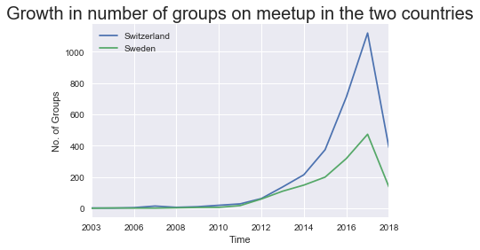

```python
country_time_series_df.plot()
plt.title("Growth in number of groups on meetup in the two countries",fontsize=20)
plt.ylabel("No. of Groups")
plt.xlabel("Time")
plt.savefig('graphs/groups_creation_country_wise-line.png',dpi=100, bbox_inches='tight')
```

This graph is showing the rise in the number of groups on yearly basis using line chart plot in the two countries. X-axis represents years and Y axis represents the number of groups formed.

#### Plot 1(b): Growth of groups comparison country-wise

##### Area Chart

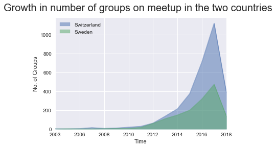

```python
country_time_series_df.plot.area(stacked=False)
plt.suptitle("Growth in number of groups on meetup in the two countries",fontsize=20)
plt.ylabel("No. of Groups")
plt.xlabel("Time")
plt.savefig('graphs/groups_creation_country_wise-area.png',dpi=100, bbox_inches='tight')
```

#### Plot 2: Growth in number of groups - monthly data

**Aim:** The aim here is to compare, which month sees highest growth in meetup groups.

**Plots Used:** Bar Charts

```python
group_month_data = pd.DataFrame([])
group_month_data = grouped_Df[['date_created']]
group_month_data = grouped_Df.assign(Month_created=pd.to_datetime(group_month_data.date_created).dt.strftime('%b'))

group_month_data.reset_index().drop(['index'],axis=1)
group_month_data = group_month_data.groupby(['Month_created'])[['Month_created']].agg('count')
group_month_data = group_month_data.rename(index=str, columns={"Month_created": "Count"}).reset_index()


# Using temp month number to sort rows
months = {datetime.datetime(2000,i,1).strftime("%b"): i for i in range(1, 13)}
group_month_data["month_number"] = group_month_data["Month_created"].map(months)
group_month_data = group_month_data.fillna(value=0).sort_values(by=['month_number']).set_index('Month_created')

group_month_data = group_month_data.drop(['month_number'], axis=1)

display(group_month_data[0:5])
```

| Month_created | Count |
| --- | --- |
| Jan | 490 |
| Feb | 470 |
| Mar | 505 |
| Apr | 333 |
| May | 375 |

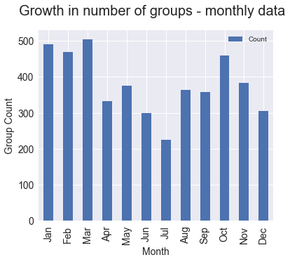

```python
p = group_month_data.plot.bar(figsize=(6,5),fontsize=14)
p.set_xlabel("Month",fontsize=14)
p.set_ylabel("Group Count",fontsize=14)

plt.suptitle("Growth in number of groups - monthly data",fontsize=20)
plt.savefig('graphs/groups_growth_monthly.png',dpi=100, bbox_inches='tight')
```

This graph is showing the rise in the number of groups on monthly basis using bar chart plot. X-axis represents months from january to december and Y axis represents the count of number of groups formed.

#### Plot 3: Growth in number of groups category-wise

**Aim:** To find out how the member accross different categories have grown since 2003

**Plots Used:** Small Multiple Bar Charts

```python
temp = grouped_Df
temp = temp.apply(pd.to_numeric, errors='ignore')

#display(temp [0:5])
members_df = temp.groupby(['category.name'])[['members']].agg('sum').sort_values(by=['members'], ascending=False).reset_index()

display(members_df[0:5])
```

|  | category.name | members |
| --- | --- | --- |
| 0 | tech | 408900 |
| 1 | career/business | 183689 |
| 2 | socializing | 125094 |
| 3 | outdoors/adventure | 122833 |
| 4 | language/ethnic identity | 105040 |

```python
#getting top 9 categories based on popularity

popular_categories = members_df[0:9]['category.name'].tolist()

cat_time_series = []

#creating array of dataframes for different categories
for p in range(len(popular_categories)):
    cat_time_series.append(grouped_Df[grouped_Df['category.name'].str.lower() == popular_categories[p]][['date_created']])
    cat_time_series[p]['date_created'] =pd.to_datetime(cat_time_series[p].date_created).dt.year
    cat_time_series[p].reset_index().drop(['index'],axis=1)
    cat_time_series[p] = cat_time_series[p].groupby(['date_created'])[['date_created']].agg('count')
    cat_time_series[p] = cat_time_series[p].rename(index=str, columns={"date_created": popular_categories[p]})


# Once categories are ready join the on the basis of index which is category name
# The groups which were existent in one country but not present in the other have been assigned a default count of 0
cat_time_series_df = pd.concat(cat_time_series, axis=1).fillna(value=0)
display(cat_time_series_df[0:5])
```

|  | tech | career/business | socializing | outdoors/adventure | language/ethnic identity | health/wellbeing | food/drink | fitness | fine arts/culture |
| --- | --- | --- | --- | --- | --- | --- | --- | --- | --- |
| 2003 | 0.0 | 1.0 | 0.0 | 0.0 | 1.0 | 0.0 | 0.0 | 0.0 | 0.0 |
| 2004 | 1.0 | 0.0 | 0.0 | 0.0 | 0.0 | 0.0 | 0.0 | 0.0 | 0.0 |
| 2006 | 1.0 | 1.0 | 1.0 | 0.0 | 0.0 | 0.0 | 1.0 | 0.0 | 0.0 |
| 2007 | 0.0 | 4.0 | 5.0 | 2.0 | 0.0 | 0.0 | 1.0 | 1.0 | 0.0 |
| 2008 | 1.0 | 1.0 | 2.0 | 0.0 | 2.0 | 1.0 | 0.0 | 0.0 | 0.0 |

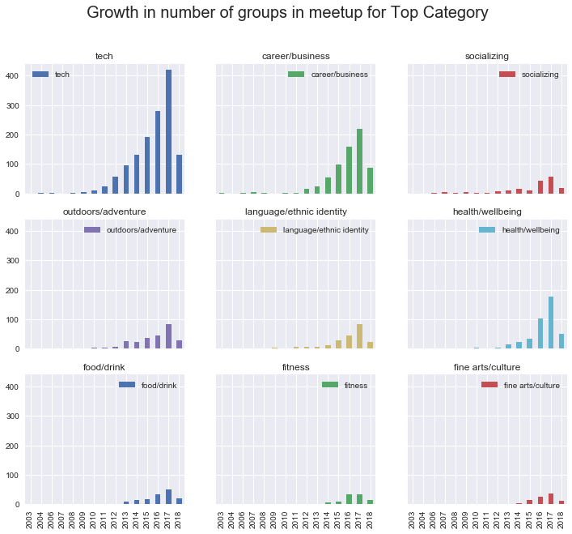

```python
ax1 = cat_time_series_df.plot(kind='bar', subplots=True, layout=(3,3), figsize=(12,10), sharey=True)
plt.suptitle("Growth in number of groups in meetup for Top Category",fontsize=20)
plt.savefig('graphs/groups_creation_category_wise.png',dpi=100, bbox_inches='tight')
```

#### Plot 4: Categories Popularity in top Global Innovative Countries

**Aim:** The aim is to find out the most popular groups. Popularity is based on the count of members that have joined a group

**Plots Used:** Treemap Charts

```python
# Custom Plot function to draw tree map
def get_treemap(sizes, norm_x=100, norm_y=100, label=None, value=None, ax=None,  **kwargs):
    if ax is None:
        ax = plt.gca()

    # create a color palette, mapped to these values
    cmap = matplotlib.cm.Wistia
    mini=min(sizes)
    maxi=max(sizes)
    norm = matplotlib.colors.Normalize(vmin=mini, vmax=maxi)
    color = [cmap(norm(value)) for value in sizes]


    # Gives Normalized values over area
    normed = squarify.normalize_sizes(sizes, norm_x, norm_y)

    # Gives rectange coordinates from Normalized values over area
    rects = squarify.squarify(normed, 0, 0, norm_x, norm_y)

    x = [rect['x'] for rect in rects]
    y = [rect['y'] for rect in rects]
    dx = [rect['dx'] for rect in rects]
    dy = [rect['dy'] for rect in rects]

    ax.bar(x, dy, width=dx, bottom=y, color=color, edgecolor='white', linewidth=1.0,
       label=label, align='edge', **kwargs)

    #Show Values (Member Count) in the center
    if not value is None:
        va = 'center' if label is None else 'top'

        #Iterate over values to add labels to axes
        for v, r in zip(value, rects):
            fz=r['dy']/2.5
            x, y, dx, dy = r['x'], r['y'], r['dx'], r['dy']
            ax.text(x + dx / 2, y + dy / 2, v, va=va, ha='center', fontsize=fz)

    #Show label (category name) in the center
    if not label is None:
        va = 'center' if value is None else 'bottom'

        #Iterate over label names to add labels to axes
        for l, r in zip(label, rects):
            fz=r['dy']/2.5
            x, y, dx, dy = r['x'], r['y'], r['dx'], r['dy']
            ax.text(x + dx / 2, y + dy / 2, l, va=va, ha='center',fontsize=fz)

    ax.set_xlim(0, norm_x)
    ax.set_ylim(0, norm_y)
    return ax
```

#### Plot 4(a): Comparison of Categories Popularity cummulatively for Top 2 Global Innovative Countries

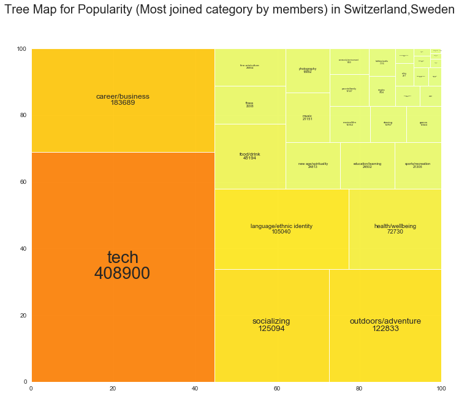

```python
members_list=members_df['members'].tolist()
label_list = members_df['category.name'].tolist()

fig1 = plt.figure(figsize=(12,10))
ax1 = fig1.add_subplot(1, 1, 1)
title = 'Tree Map for Popularity (Most joined category by members) in ' + ",".join(grouped_Df['country_name'].unique().tolist())
fig1.suptitle(title, fontsize=20)
get_treemap(sizes=members_list, label=label_list, value=members_list, alpha=0.9, ax=ax1)
#ax1.set_axis_off()
fig1.savefig('graphs/treeMap.png', dpi=100, bbox_inches='tight')
plt.show(fig1)
```

This tree map shows the popularity of the categories based on the number of members who joined it. The data has been normalized on the scale of (100,100) to get the uniform boxes.

#### Plot 4(b): Comparison of Top 2 Global Innovative Countries Categories Popularity

```python
temp = grouped_Df

temp = temp.apply(pd.to_numeric, errors='ignore')

#display(temp [0:5])
members_country = temp.groupby(['category.name','country_name'])[['members']].agg('sum').sort_values(by=['members'], ascending=False).reset_index()

display(members_country[0:5])
```

|  | category.name | country_name | members |
| --- | --- | --- | --- |
| 0 | tech | Sweden | 240087 |
| 1 | tech | Switzerland | 168813 |
| 2 | outdoors/adventure | Switzerland | 109286 |
| 3 | career/business | Switzerland | 99586 |
| 4 | career/business | Sweden | 84103 |

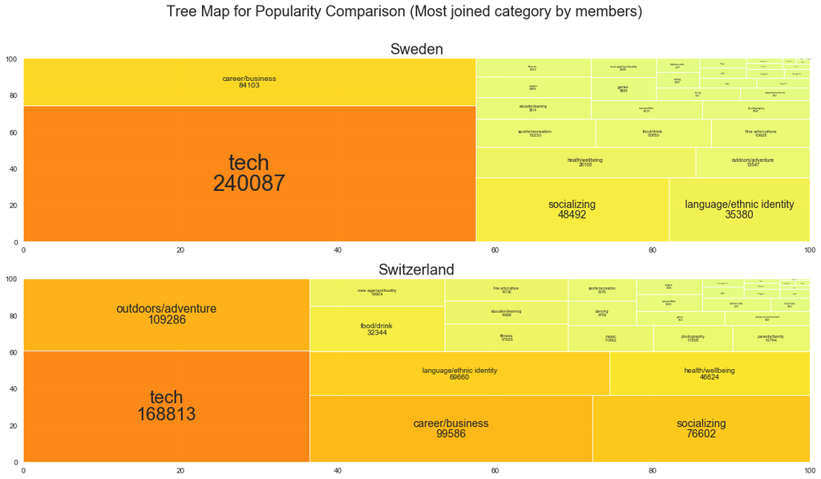

```python
countries = members_country['country_name'].unique().tolist()

fig2, ax = plt.subplots(2)

title = 'Tree Map for Popularity Comparison (Most joined category by members)'

fig2.suptitle(title, fontsize=20)
member = pd.DataFrame([])
member = []
members_list = []
label_list=[]

for i in range(len(countries)):
    member = members_country[members_country['country_name'] == countries[i]]
    members_list=member['members'].tolist()
    label_list = member['category.name'].tolist()

    get_treemap(sizes=members_list, label=label_list, value=members_list , alpha=0.9, ax=ax[i])
    ax[i].set_title(countries[i], fontsize=20)
    #ax[i].set_axis_off()
    ax[i].figure.set_size_inches(19, 10)

fig2.savefig('graphs/treeMap-comapre.png', dpi=100, bbox_inches='tight')
plt.show(fig2)
```

This tree map shows the popularity of the categories based on the number of members who joined it but using subplots to comapre data for two countries. The data has been normalized on the scale of (100,100) to get the uniform boxes.

#### Plot 5: Compare ratings of different categories for the selected countries

**Aim:** The idea is to compare what are the trends for ratings in the differnt countries based on categories

**Plots Used:** Bar Plot and Stacked Bar Plot

```python
#display(temp [0:5])
category_rating = temp.groupby(['category.name','country_name'])[['rating']].agg('mean').sort_values(by=['rating'], ascending=False).reset_index()

display(category_rating[0:5])
```

|  | category.name | country_name | rating |
| --- | --- | --- | --- |
| 0 | sci-fi/fantasy | Switzerland | 4.890000 |
| 1 | book clubs | Switzerland | 4.254444 |
| 2 | dancing | Sweden | 4.154444 |
| 3 | writing | Sweden | 3.828000 |
| 4 | photography | Sweden | 3.770556 |

```python
# Min-Max Normalization to create a new column normalized_rating
# By creating new column, one can easily compare values before and after normalization
category_rating['normalized_rating']=(category_rating['rating']-category_rating['rating'].min())/(category_rating['rating'].max()-category_rating['rating'].min())
category_rating[0:5]
```

|  | category.name | country_name | rating | normalized_rating |
| --- | --- | --- | --- | --- |
| 0 | sci-fi/fantasy | Switzerland | 4.890000 | 1.000000 |
| 1 | book clubs | Switzerland | 4.254444 | 0.870030 |
| 2 | dancing | Sweden | 4.154444 | 0.849580 |
| 3 | writing | Sweden | 3.828000 | 0.782822 |
| 4 | photography | Sweden | 3.770556 | 0.771075 |

```python
countries = category_rating['country_name'].unique().tolist()

# Modify the structure of data and make different columns for the different countries
df_arr = []
for i in range(len(countries)):
    df_arr.append(category_rating[category_rating['country_name']==countries[i]])
    df_arr[i] = df_arr[i].drop(['rating','country_name'], axis=1).set_index('category.name').rename(index=str, columns={"normalized_rating": countries[i]})

cat_rating_df = pd.concat(df_arr, axis=1, join="inner")
display(cat_rating_df[0:5])
```

| category.name | Switzerland | Sweden |
| --- | --- | --- |
| sci-fi/fantasy | 1.000000 | 0.659168 |
| book clubs | 0.870030 | 0.546779 |
| singles | 0.682734 | 0.442740 |
| tech | 0.622019 | 0.627446 |
| movies/film | 0.601113 | 0.397702 |

##### Plot 5(a): Bar Plot

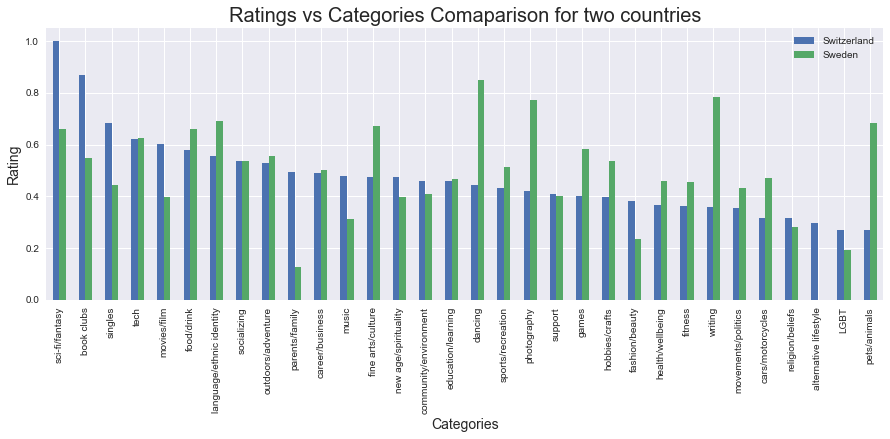

```python
axes = cat_rating_df.plot.bar(figsize=(15,5))
axes.set_xlabel("Categories",fontsize=14)
axes.set_ylabel("Rating",fontsize=14)
axes.set_title("Ratings vs Categories Comaparison for two countries",fontsize=20)
plt.savefig('graphs/category_ratings.png',dpi=100, bbox_inches='tight')
```

This graph represnts the rating vs categories bar plot for comparing two countries. The rartings have been normalized using min-max normalization. Once this has been done, the ratings are now plotted against the categories to find out patterns. X-axis represents categories and Y -axis represents normalized ratings.

##### Plot 5(b): Stacked Bar Plot

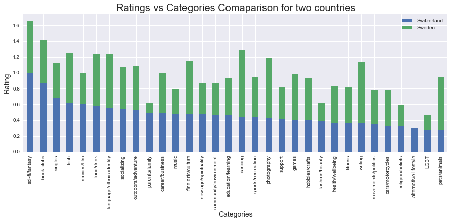

```python
axes = cat_rating_df.plot.bar(stacked=True,figsize=(15,5))
axes.set_xlabel("Categories",fontsize=14)
axes.set_ylabel("Rating",fontsize=14)
axes.set_title("Ratings vs Categories Comaparison for two countries",fontsize=20)
plt.savefig('graphs/category_ratings_stacked.png',dpi=100, bbox_inches='tight')
```

This graph represnts the rating vs categories stacked bar plot for comparing two countries. The rartings have been normalized using min-max normalization. Once this has been done, the ratings are now plotted against the categories to find out patterns. X-axis represents categories and Y -axis represents normalized ratings.

#### Plot 6: Members vs Rating vs No. of Groups to Rating for Different Categories

**Aim:** The aim is to find out the relation between ratings, members in group and groups count

**Plots Used:** Scatter Plot, Scatter Matrix(Small Multiples), Line Chart(Small Multiples), Dual Axis Chart

```python
category_rating_dual = temp.groupby(['category.name'])[['rating']].agg('mean').reset_index().set_index('category.name').rename(index=str, columns={"rating": "mean_rating"})
groups_df = temp.groupby(['category.name'])[['id']].agg('count').reset_index().set_index('category.name').rename(index=str, columns={"id": "group_count"})
members_df_copy = members_df.set_index('category.name')

cat_data_unnormalized = pd.concat([members_df_copy, category_rating_dual,groups_df], axis=1)

display(cat_data_unnormalized[0:5])
```

|  | members | mean_rating | group_count |
| --- | --- | --- | --- |
| LGBT | 4282 | 1.205313 | 32 |
| alternative lifestyle | 449 | 1.357143 | 14 |
| book clubs | 4802 | 3.242800 | 25 |
| career/business | 183689 | 2.423424 | 663 |
| cars/motorcycles | 628 | 1.690909 | 11 |

```python
# Normalization of data using min-max normalization

cat_data = pd.DataFrame(cat_data.index.tolist()).set_index(0).rename_axis('Categories')


cat_data['mean_rating']=(cat_data_unnormalized['mean_rating']-cat_data_unnormalized['mean_rating'].min())/(cat_data_unnormalized['mean_rating'].max()-cat_data_unnormalized['mean_rating'].min())
cat_data['members']=(cat_data_unnormalized['members']-cat_data_unnormalized['members'].min())/(cat_data_unnormalized['members'].max()-cat_data_unnormalized['members'].min())
cat_data['group_count']=(cat_data_unnormalized['group_count']-cat_data_unnormalized['group_count'].min())/(cat_data_unnormalized['group_count'].max()-cat_data_unnormalized['group_count'].min())

display(cat_data[0:5])
```

| Categories | mean_rating | members | group_count |
| --- | --- | --- | --- |
| LGBT | 0.297119 | 0.010358 | 0.022371 |
| alternative lifestyle | 0.334546 | 0.000983 | 0.008949 |
| book clubs | 0.799376 | 0.011630 | 0.017151 |
| career/business | 0.597393 | 0.449164 | 0.492916 |
| cars/motorcycles | 0.416822 | 0.001421 | 0.006711 |

#### Plot 6(a): Scatter Plot

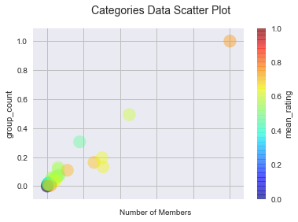

```python
ax = cat_data.plot.scatter(x="members", y="group_count", c='mean_rating', cmap = matplotlib.cm.jet, alpha=0.4 , s=250)
ax.grid(True,linestyle='-',color='0.75')

ax.text(0.75, -0.1, 'Number of Members',
        verticalalignment='bottom', horizontalalignment='right',
        transform=ax.transAxes)

plt.suptitle("Categories Data Scatter Plot",fontsize=14)
plt.savefig('graphs/scatter_plot_categories.png',dpi=100, bbox_inches='tight')
```

#### Plot 6(b): Scatter Matrix

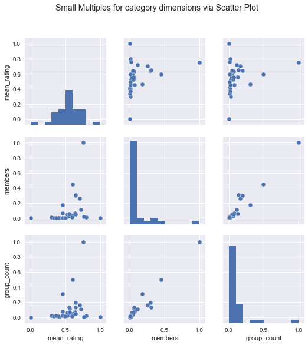

```python
sns.pairplot(cat_data)
ax = plt.gca()
plt.suptitle("Small Multiples for category dimensions via Scatter Plot",fontsize=14, y=1.08)
plt.savefig('graphs/scatter_categories_small_multiple.png',dpi=100, bbox_inches='tight')
```

This graph represents the scatter matrix plot for mean rating, number of members and group count. The data has been normalized already using min-max normalization. The other half of the graph is identical.

#### Plot 6(c): Small Multiples Line Chart

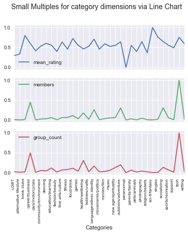

```python
axes = cat_data.plot(rot=90,subplots=True, figsize=(6, 6),x_compat=True);
plt.xticks(range(len(cat_data.index.tolist())), cat_data.index.tolist(), size='small')

plt.suptitle("Small Multiples for category dimensions via Line Chart",fontsize=14)
plt.savefig('graphs/line_categories_small_multiple.png',dpi=100, bbox_inches='tight')
```

#### Plot 6(d): Dual Axes Line Chart

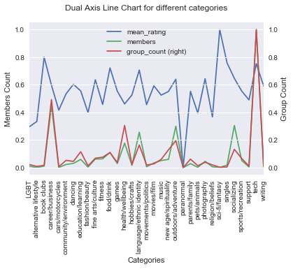

```python
ax = cat_data.plot(rot=90,secondary_y=['group_count'])
ax.set_ylabel("Members Count")
ax.right_ax.set_ylabel("Group Count")
plt.xticks(range(len(cat_data.index.tolist())), cat_data.index.tolist(), size='small')
plt.title("Dual Axis Line Chart for different categories\n")
plt.xlabel("Time")

plt.savefig('graphs/line_categories_dual_axes.png',dpi=100, bbox_inches='tight')
```

#### Plot 7: Frequency Distribution for groups in different cities of one country

**Aim:** The aim is to find out which city has more number of groups

**Plots Used:** Bar Chart - frequeny distribution

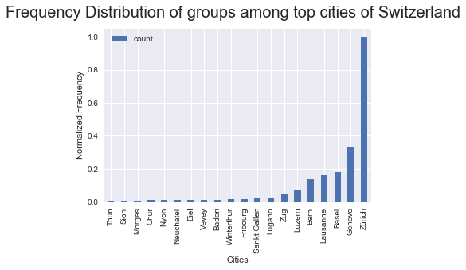

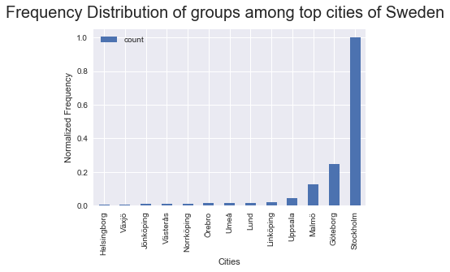

```python
from collections import Counter

city_data = temp[['city','country_name']]
countries = city_data['country_name'].unique().tolist()

for i in range(len(countries)):
    a = city_data.loc[city_data['country_name'] == countries[i]]['city'].tolist()
    letter_counts = Counter(a)
    df = pd.DataFrame.from_dict(letter_counts, orient='index')
    df.columns = ['count']
    df['count']=(df['count']-df['count'].min())/(df['count'].max()-df['count'].min())

    threshold = 0.005
    # Remove rows less than the threshold
    df = df[df['count'] > threshold].sort_values(by=['count'])
    df.plot(kind='bar')
    plt.suptitle("Frequency Distribution of groups among top cities of "+countries[i],fontsize=20)
    plt.ylabel("Normalized Frequency")
    plt.xlabel("Cities")
    plt.savefig("graphs/groups_distribution_city_wise"+countries[i]+".png",dpi=100, bbox_inches='tight')
```

### 5.2. Interpretations and Data Insights

There are many conclusions that can be drawn from the given graphs before:

1. Plot 1: Comparison of growth of groups for two countries

   It can be clearly seen from the graphs that both the innovative countries are showing growth in the group count over the years. But the point specifically to be noted is Switzerland is ranked first in Global innovation index and Sweden as second. The groups count is more in Switzerland than in Sweden and the gap in increasing. Considering, year 2018 is not complete yet, trend says, in 2018 the number groups will increase
2. Plot 2: Growth in number of groups - monthly data

   There is no clear trend for the increase in the groups growth accross the different months. However, the starting months January, February and March saw the major growth.
3. Plot 3: Growth in number of groups category-wise

   It can be clearly figured out that the innovative countries are focussing more on Technology field and have been joining it in more and more numbers. Also, people in these countries are more focussed on career / business. Though this field is behind technology but the gap in number of members in career/ business and other categories is significant. Apart from them, health/ well being has seen a good growth in year 2017.
4. Plot 4: Categories Popularity in top Global Innovative Countries

   ```
    Like the previous graphs, we are now comparing categories based on member count:

    - The top joined categories are: tech, socializing, career/business and outdoor adventures
    - Also, if we compare the previous graph with this one, we will find out that even though socializing category does not have too many groups but still it has a lot of members

    Comparison between Switzerland and Sweden:

    - Sweden is showing a bias towards tech. Tech is also the most joined category in Switzerland but it's people are still joining other groups as well and the gap is smaller.
   ```

   This means country focussing on all the fields is more innovative than others which is biased towards one field.
5. Plot 5: Compare ratings of different categories for the selected countries

   This data shows that there is no clear trend in the ratings provided by the users. Less number of members could be the reason for irregular trends. However, one point to be noted is that the categories which have the highest number of members in the two countries share the similar or slightly different rating for those categories like tech, socializing, career/business and outdoor adventures
6. Plot 6: Members vs Rating vs No. of Groups to Rating for Different Categories

   As in the previous graphs, these graphs also depict no clear picture for rating, but the trends is strong, whcih suggests as the number groups increases, member counts also increases. As seen in the dual axes chart for members and group count or in Small Multiple of line chart.
7. Plot 7: Frequency Distribution for groups in different cities of one country

#### Tentative Conclusion:

Any country which wants to increase it's rank in the global innovation index can take insights from this experiement and encourage more groups which leads to innovation.  
Higher the number of groups, more are the members.  
Higher the number of groups, more is the global innovation index.

### 5.3. Future Scope

More statisfical modelling can be applied to this data to find out that there is strong relation between number of groups and members and the countries with high global innovation index are involved more in meetups. Currently, only two countries were selected.

But Limited data was collected since the resources and time was limited. More data can be picked from around the world for multiple countries and staistical modelling can be perfromed on the various countries data to compare data.

The members details and the events around the world is a high volumetric data and could not be picked since it require high memory constraints. Also, further since it give coordinates(latitude, longitude), success of a group can be discovered using more detailed data which can be used by companies to share their new innovations. Companies can also benefit from the data, because before organizing any event they might analyze success of the event based on numbers.

Meetup provides more set of open APIs.

For example:

1. Member details and how many groups they have joined. This can be used to track the activity and trends for the members and give then tailored recommendations. Also, countries can promote categories among members if the country is lagging behind in a category which is highly joined by innovative countries.
2. It also gives venue data. So, the numbers members attending an event may depend on venues and further data can be analyzed to select top venues having a high turnout ratio.

#### References:

1. Slides by Mr. Derek Greene for Module Data Science in Python
2. http://pandas.pydata.org/
3. https://github.com/laserson/squarify/
4. https://matplotlib.org/
5. https://seaborn.pydata.org/examples/scatterplot_matrix.html